# 1. Preprocessing of hyper spectral images

Processing of hyperspectral images includes three important steps to be performed as per need.

- Identification and removal of noisy bands
- Removal of null-fills (for e.g pixels with reflectance value -9999.0). It is important if an image contains any pixels which are not part of actual scene.
- Masking of non-vegetation pixels.

## Load the hyperspeclib library

```python
import hyspeclib as hy
```

## Define all the paths

```python
##  Path to main directory
our_data_dir = 'anand/'

##  Unprocessed image directory
our_image_dir = our_data_dir+'Raw_images/'

## Path to the image be used for preprocessing
our_image_path = our_image_dir+'unprocessed/unprocessed_image.hdr'

##  Path to output directory where preprocessed image will be saved.
pre_save_dir = our_data_dir+'Preprocessed_image/'
```

## Loading Raw Image and checking height, width and total number of bands

```python
image = hy.read_image(our_image_path)
```

```python
print('Number of bands :',image.img_bands)
print('Image height :',image.img_height)
print('Image width :',image.img_width)
```

```
Number of bands : 425
Image height : 300
Image width : 393
```

## Step 1 - Noisy bands detection

#### For removal of fraunhofer lines, we can set maximum reflectance value as 1 and minimum reflectance value as 0.

```python
noisy_bands_info = hy.noise_removal(image, min_threshold = 0, max_threshold = 1)
```

#### Visualisation of range of reflectance values in each bands for given image

The dotted lines show the maximum and minimum value allowed for reflectance for each band. Bands outside the inner part of dotted lines can be considered as removed.

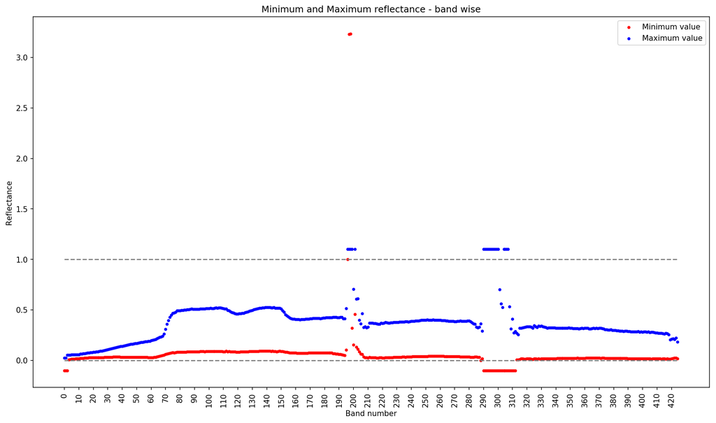

```python
noisy_bands_info.reflectance_plot()
```

#### Statistics for given image includes maximum, mean, (mean + 2xSigma), (mean - 2xSigma), Standard deviation of all reflectance values.

Even after removal of fraunhofer lines, some noisy bands are remaining which can be removed through proper thresold of maximum reflectance value.

```python
noisy_bands_info.mean_stat()
```

```
{'max': 0.7062405,
 'mean': 0.16543758,
 'mean + 2*sigma': 2.639236092567444,
 'mean - 2*sigma': -2.3083609342575073,
 'min': 0.00034409194,
 'stdv': 1.2368993}
```

#### Selecting bands with only reflectance value between 0 and max value (here 0.55)

```python
noisy_bands_info = hy.noise_removal(image, min_threshold = 0, max_threshold = 0.55)
```

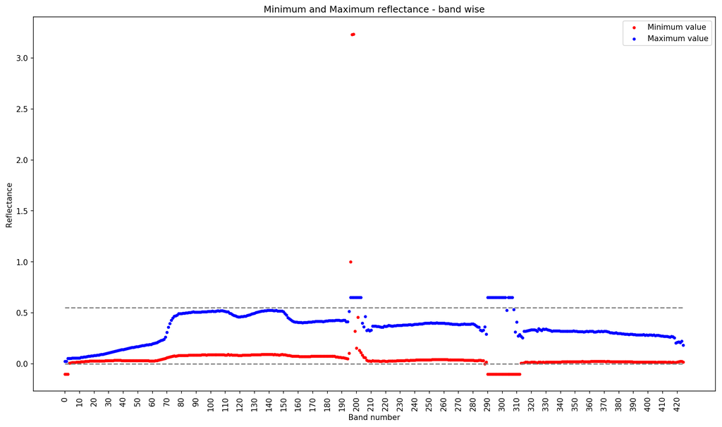

```python
noisy_bands_info.reflectance_plot()
```

#### List of noisy bands with the minimum and maximum value of reflectance

```python
print("--------- List of noisy bands ---------")
noisy_bands_info.show_noisy_bands_with_min_max()
```

```
--------- List of noisy bands ---------
```

```
[(0, -0.004925476, 0.023974443),
 (1, -0.00092434185, 0.025517834),
 (2, -0.00044369636, 0.054534975),
 (196, 1.0006491, 6.2307205),
 (197, 3.2283175, 28.862068),
 (198, 3.2342486, 25.140608),
 (199, 0.31904712, 1.5330484),
 (200, 0.15408023, 0.7062405),
 (201, 0.45762303, 3.9798782),
 (202, 0.13401343, 0.60886395),
 (203, 0.11217423, 0.61088246),
 (290, -0.14219935, 1.0380087),
 (291, -4.9735317, 18.169424),
 (292, -26.933197, 47.18488),
 (293, -1.634299, 3.5738058),
 (294, -2.5168257, 7.248437),
 (295, -3.633431, 14.122553),
 (296, -2.4177022, 6.4896426),
 (297, -0.3969328, 1.8057275),
 (298, -2.5399668, 4.6726427),
 (299, -6.389768, 17.949532),
 (300, -0.40353727, 1.2678614),
 (301, -0.25679904, 0.70010936),
 (302, -0.109293625, 0.56055313),
 (303, -0.20577697, 0.5249394),
 (304, -0.42758185, 1.1891016),
 (305, -8.138784, 27.858128),
 (306, -2.4245825, 7.083447),
 (307, -0.43808395, 1.6269228),
 (308, -0.1394753, 0.5329536),
 (309, -0.08115421, 0.31171006),
 (310, -0.086150914, 0.41048175),
 (311, -0.018062774, 0.27391008),
 (312, -0.010429804, 0.28637552)]
```

```python
x = noisy_bands_info.show_noisy_bands()
print(len(x)," : ",x)
```

```
34  :  [0, 1, 2, 196, 197, 198, 199, 200, 201, 202, 203, 290, 291, 292, 293, 294, 295, 296, 297, 298, 299, 300, 301, 302, 303, 304, 305, 306, 307, 308, 309, 310, 311, 312]
```

## Step 2 - Removal of noisy bands, zero fills and non-vegetation pixels

- **available_memory_gb** : you can specify the maximum available memory to load image into RAM at a time in GB

```python
pre = hy.preprocessing(img_path = our_image_path, save_directory = pre_save_dir, available_memory_gb=0.12)
```

```
Image will be saved in 2 partitions.
```

- **ndvi_threshold** : maximum value of scaled NDVI for non-vegetation pixels.
- **data_ignore_value=** : Value used for out of scene pixels. It is specified in header file
- **NIR** : Band number to be used as NIR chennel for NDVI calculation
- **RED** : Band number to be used as RED chennel for NDVI calculation
- **noisy_bands** : Manually specify the list of bands to be removed. If not specified then noisy bands will be automatically identified bansed on min_threshold and max_threshold

```python
pre.perform(ndvi_threshold=125,
            data_ignore_value=-9999.0,
            NIR=90,
            RED=55,
            min_threshold=0,
            max_threshold=0.55,
            noisy_bands=x)
```

```
--------------- Performing Preprocessing ---------------


Partition : 1 / 2 running...

Saving /Users/hetulpatel/Documents/major/code12062018/anand/Preprocessed_image/unprocessed_image_part_1

Partition : 2 / 2 running...

Saving /Users/hetulpatel/Documents/major/code12062018/anand/Preprocessed_image/unprocessed_image_part_2

Preprocessing completed. Output directory : anand/Preprocessed_image/


---------------------------------------------------------
```

## Open and check preprocessed image

```python
pre_image = hy.read_image(pre_save_dir+'unprocessed_image_part_1.hdr')
```

```python
print('Number of bands :',pre_image.img_bands)
print('Image height :',pre_image.img_height)
print('Image width :',pre_image.img_width)
```

```
Number of bands : 391
Image height : 179
Image width : 393
```